# Corrected R-squared

Authors

Lisa Nicvert

Hervé Fritz

Stéphane Dray

```r
library(here)

library(ggplot2)

library(dplyr)

library(ade4)
library(adegraphics)

devtools::load_all()
```

```r
set.seed(42)

figures_folder <- here("figures")
output_folder <- here("outputs", "04_corrected_R2")
```

## Introduction

The aim of this analysis is to propose the following measures for double-constrained analyses:

- a permutation test that has the expected rate of false positives (less than risk $\alpha$)
- a correction for the R-squared

Peres-Neto et al. (2006) proposed a $R^2$ correction for CCA based on permutations, but no correction has been proposed for dc-CA. However, Dray and Legendre (2008) proposed a permutation test for species-environment links with the fourth-corner method: here, we can try to combine both approaches to propose a corrected $R^2$ and an adapted permutation test for dc-CA.

## The problem

When there are 3 tables (let’s call them $\mathbf{R}$ for row variables, $\mathbf{L}$ for the observed table, $\mathbf{Q}$ for column variables), there can be 3 types of links:

- link only between $\mathbf{R}$ and $\mathbf{L}$;
- link only between $\mathbf{Q}$ and $\mathbf{L}$;
- link only between $\mathbf{R}$ and $\mathbf{Q}$ (this is what we want to test and $H_1$);

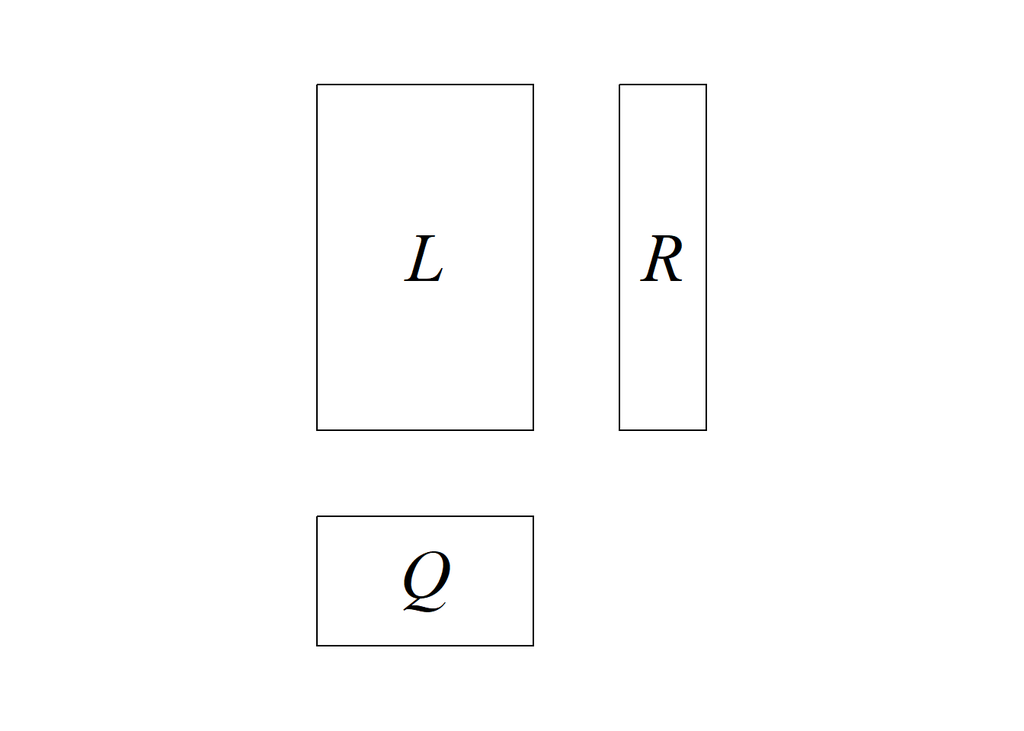

```r
plotmat(E = TRUE, T_ = TRUE,
        r = 8, c = 5,
        l = 2, k = 3,
        name_dim = FALSE,
        Yname = "italic(L)",
        Ename = "italic(R)",
        Tname = "italic(Q)")
```

Alternatively, there can be no link between $\mathbf{R}$ and $\mathbf{Q}$. Our issue is that $H_0$ should encompass the case above (no link), but also the links between one of the two tables $\mathbf{R}$ or $\mathbf{Q}$ and $\mathbf{L}$; if only the absence of link between $\mathbf{R}$ and $\mathbf{Q}$ is tested, we risk having too many false positives compared to the chosen risk $\alpha$.

for the same reason, the observed $R^2$ supposed to give the link between $\mathbf{R}$ and $\mathbf{Q}$ might be overestimated if there is a link between $\mathbf{R}$ and $\mathbf{L}$ or $\mathbf{Q}$ and $\mathbf{L}$, but no link between $\mathbf{R}$ and $\mathbf{Q}$.

## The solution

To answer this problem, we rely on a permutation approach for testing and for correcting the $R^2$ (here, it is noted $R^2_{\mathbf{L}|\mathbf{R},\mathbf{Q}}$) (similarly to Peres-Neto et al. (2006)). To do that, we adapt the permutation approach proposed by Dray and Legendre (2008) in the context of fourth-corner analysis to dc-CA.

## Simulations

```r
# Simulation parameters
nresource <- 20
nconsumer <- 30
sd_tol <- 0.1
mean_tol <- 5
ninter <- 500
delta <- 1

le.grad <- 100
buffer <- 0
ratio.grad <- 0.7

meanlog <- log(3)
sdlog <- log(1.5)
```

```r
start <- Sys.time()
res_df <- data.frame()
for (rep in 1:params$nrep) {
  # Simulate data ---
  print(paste0("Simu ", rep, "/", params$nrep, "----------"))
  consumerab <- rlnorm(nconsumer,
                     meanlog = meanlog,
                     sdlog = sdlog)
  resourceab <- rlnorm(nresource,
                       meanlog = meanlog,
                       sdlog = sdlog)

  sim <- compas2d(nsp = nconsumer,
                  nsite = nresource,
                  le.grad = le.grad,
                  col_prefix = "c",
                  row_prefix = "r",
                  rowvar_prefix = "tr",
                  remove_zeroes = FALSE,
                  col_abund = consumerab,
                  row_abund = resourceab,
                  ninter = ninter,
                  ratio.grad = ratio.grad,
                  mean.tol = mean_tol,
                  sd.tol = sd_tol,
                  delta = delta,
                  buffer = buffer)

  comm <- data.frame(sim$comm)
  resource_traits <- data.frame(sim$rowvar)
  consumer_traits <- data.frame(sim$colvar[, "mean", ])

  # Add random traits ---
  randr <- matrix(rnorm(n = nresource*3),
                  ncol = 3)
  randc <- matrix(rnorm(n = nconsumer*3),
                  ncol = 3)
  resource_traits <- cbind(resource_traits, randr)
  consumer_traits <- cbind(consumer_traits, randc)

  # Randomize traits ---
  rand_resource <- sample(1:nresource,
                          size = nresource, replace = FALSE)
  rand_consumer <- sample(1:nconsumer,
                          size = nconsumer, replace = FALSE)
  resource_traits_perm <- resource_traits[rand_resource, ]
  consumer_traits_perm <- consumer_traits[rand_consumer, ]

  traits_list <- list("rperm" = list("r" = resource_traits_perm,
                                     "c" = consumer_traits),
                      "cperm" = list("r" = resource_traits,
                                     "c" = consumer_traits_perm),
                      "rcperm" = list("r" = resource_traits_perm,
                                      "c" = consumer_traits_perm),
                      "noperm" = list("r" = resource_traits,
                                      "c" = consumer_traits))

  # Variation partitioning ---
  ca <- dudi.coa(comm, nf = 2, scannf = FALSE)

  vp <- lapply(names(traits_list),
               function(nam) {
                 dvaripart(Y = ca,
                           dfR = traits_list[[nam]]$r,
                           dfQ = traits_list[[nam]]$c)})
  names(vp) <- names(traits_list)

  # Get p-values
  pval <- sapply(vp, function(v) max(v$test$pvalue[c(3, 4)]))

  # Get observed R2
  R2_obs <- sapply(vp, function(v) unname(v$R2["b"]))

  # Get corrected R2
  R2_corr <- sapply(vp, function(v) unname(v$R2.adj["b"]))

  res_df_rep <- data.frame(perm = names(traits_list),
                           pval = pval,
                           R2_obs = R2_obs,
                           R2_corr = R2_corr)
  res_df <- rbind(res_df, res_df_rep)
}
end <- Sys.time()
print(end-start)

# Save results
if (!dir.exists(output_folder)) {
    dir.create(output_folder, recursive = TRUE, showWarnings = FALSE)
}
saveRDS(res_df, file.path(output_folder, "R2.rds"))
```

```r
# Read results
res_df <- readRDS(file.path(output_folder, "R2.rds"))
```

## Results

### Plot R2

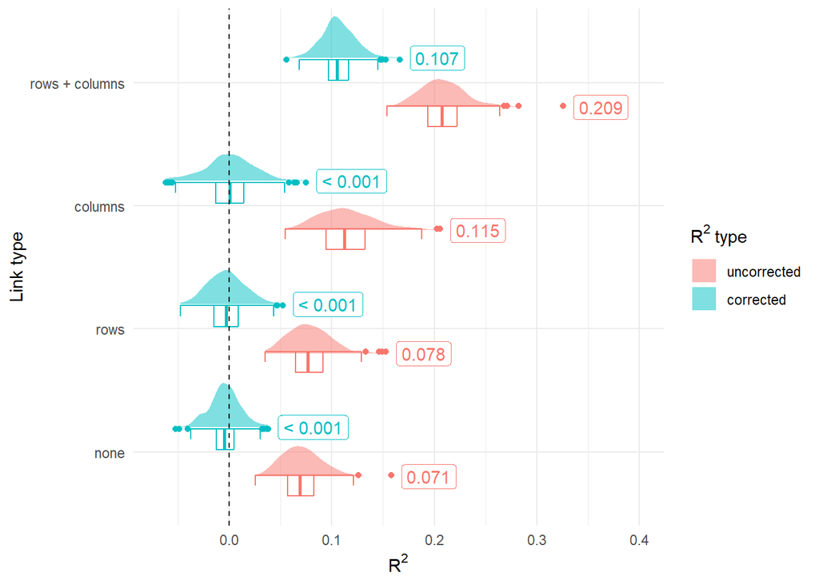

```r
# Prepare data
res_df$perm_label <- factor(res_df$perm,
                            levels = c("noperm", "rperm",
                                       "cperm", "rcperm"),
                            labels = c("rows + columns", "columns",
                                       "rows", "none"))

res_R2 <- res_df |>
  dplyr::select(perm, perm_label, starts_with("R2")) |>
  tidyr::pivot_longer(cols = starts_with("R2"),
                      names_to = "type",
                      values_to = "R2")
res_R2$type_label <- factor(res_R2$type,
                            levels = c("R2_obs", "R2_corr"),
                            labels = c("uncorrected", "corrected"))

R2_mean <- res_R2 |>
  dplyr::group_by(perm_label, type_label) |>
  dplyr::summarize(R2_mean = mean(R2),
                   R2_max = max(R2) + 0.03) |>
  dplyr::mutate(R2_label = ifelse(R2_mean < 0.001,
                                  "< 0.001", as.character(round(R2_mean, 3))))
# Plot
ggplot(res_R2) +
  gghalves::geom_half_boxplot(aes(y = R2, x = perm_label,
                                  color = type_label),
              position = "dodge2",
              show.legend = FALSE) +
  ggdist::stat_slab(aes(y = R2, x = perm_label,
                        fill = type_label),
                    alpha = 0.5,
                    width = 0.8,
                    position = position_dodge(0.8)) +
  geom_hline(yintercept = 0.0, linetype = "dashed") +
  geom_label(data = R2_mean,
             aes(y = R2_max - 0.02, x = perm_label,
                 label = R2_label,
                 col = type_label),
                 position = position_dodge(width = 0.8),
                 hjust = 0,
             show.legend = FALSE) +
  scale_x_discrete(limits = rev) +
  scale_y_continuous(limits = c(-0.07, 0.4)) +
  xlab("Link type") +
  ylab(expression(R^2)) +
  labs(fill = expression(R^2~"type")) +
  theme_minimal() +
  coord_flip()
```

```r
ggsave(file.path(figures_folder, "Fig_S1_S5a_R2_comparison.png"),
       width = 16, height = 10, units = "cm", bg = "white")
```

```r
res_R2 |>
  group_by(perm_label, type_label) |>
  summarize(R2 = mean(R2), .groups = "drop") |>
  DT::datatable() |>
  DT::formatRound(columns = "R2")
```

|  | perm_label | type_label | R2 |
| --- | --- | --- | --- |
| 1 | rows + columns | uncorrected | 0.2087114071871521 |
| 2 | rows + columns | corrected | 0.1065324973872613 |
| 3 | columns | uncorrected | 0.1148196217379614 |
| 4 | columns | corrected | 0.0004228631443781491 |
| 5 | rows | uncorrected | 0.0779257501668165 |
| 6 | rows | corrected | -0.00238122136322984 |
| 7 | none | uncorrected | 0.0708238028814129 |
| 8 | none | corrected | -0.004058482918677455 |

### Plot pvalues

```r
# Prepare data
pval_prop <- res_df |>
  dplyr::mutate(signif = pval < 0.05) |>
  dplyr::group_by(perm_label) |>
  dplyr::summarize(prop_signif = sum(signif)/n()) |>
  dplyr::mutate(prop_signif_label = ifelse(prop_signif < 0.001 & prop_signif != 0,
                                           "< 0.001", as.character(round(prop_signif, 3))))
```

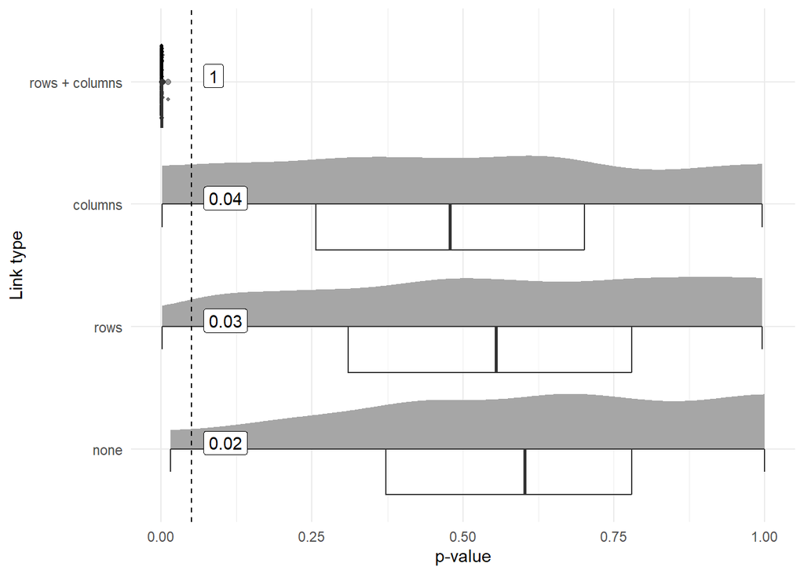

```r
ggplot(res_df) +
  geom_jitter(data = res_df |>
                      filter(perm_label == "rows + columns"),
              aes(y = pval, x = perm_label),
              width = 0.3, height = 0,
              size = 0.8, alpha = 0.5) +
  ggdist::stat_slab(data = res_df |>
                      filter(perm_label != "rows + columns"),
                    aes(y = pval, x = perm_label),
                    width = 0.5) +
  gghalves::geom_half_boxplot(aes(y = pval, x = perm_label),
                              alpha = 0.5) +
  geom_hline(yintercept = 0.05, linetype = "dashed") +
  geom_label(data = pval_prop,
            aes(y = 0.07, x = perm_label,
                label = prop_signif_label),
                hjust = 0, nudge_x = 0.05) +
  scale_x_discrete(limits = rev) +
  ylim(0, 1) +
  ylab("p-value") +
  xlab("Link type") +
  theme_minimal() +
  coord_flip()
```

```r
ggsave(file.path(figures_folder, "Fig_S1_S5b_pval_distri.png"),
       width = 14, height = 10, units = "cm",
       bg = "white")
```

```r
# Show tabulated results
res_df |>
  group_by(perm_label) |>
  summarize(pvalue_mean = mean(pval), .groups = "drop") |>
  DT::datatable() |>
  DT::formatRound(columns = "pvalue_mean")
```

|  | perm_label | pvalue_mean |
| --- | --- | --- |
| 1 | rows + columns | 0.00109 |
| 2 | columns | 0.49047 |
| 3 | rows | 0.5399033333333333 |
| 4 | none | 0.57276 |

## References

Dray, Stéphane, and Pierre Legendre. 2008. “Testing the Species Traits–Environment Relationships: The Fourth-Corner Problem Revisited.” *Ecology* 89 (12): 3400–3412. https://doi.org/10.1890/08-0349.1.

Peres-Neto, Pedro R., Pierre Legendre, Stéphane Dray, and Daniel Borcard. 2006. “Variation Partitioning of Species Data Matrices: Estimation and Comparison of Fractions.” *Ecology* 87 (10): 2614–25. https://doi.org/10.1890/0012-9658(2006)87[2614:VPOSDM]2.0.CO;2.